# 2023年巴菲特致股东的信

2024年2月25日

沃伦-巴菲特

董事会主席

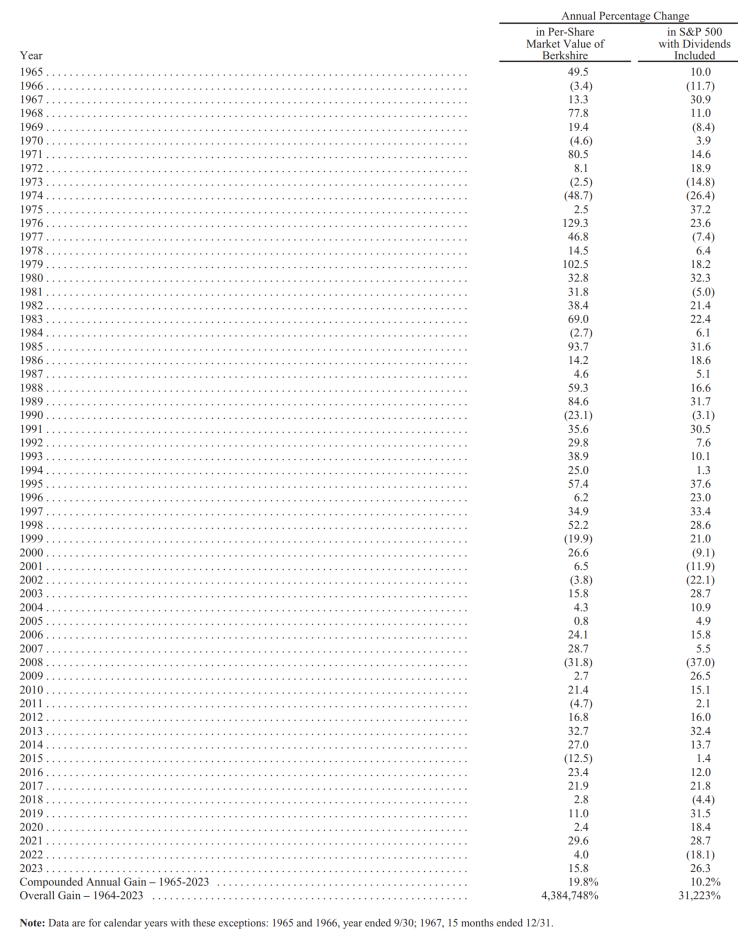

**查理·芒格——伯克希尔·哈撒韦的设计师**

查理·芒格于11月28日去世，距离他的100岁生日仅差33天。

尽管他出生并成长于奥马哈，但他80%的时间都生活在其他地方。因此，直到1959年他35岁时，我才第一次见到他。1962年，他决定从事金融管理。

三年后，他告诉我——准确地说！——我在收购伯克希尔公司时做了一个愚蠢的决定。但是，他向我保证，既然我已经迈出了这一步，他会告诉我如何纠正我的错误。

在我接下来要讲的故事中，请记住，查理和他的家人在我当时管理的小型投资合伙企业中没有一分钱投资，而我用这些钱购买了伯克希尔。此外，我们俩都没有预料到查理会拥有伯克希尔公司的股份。

然而，1965年，查理及时建议我：“沃伦，别再想着购买另一家像伯克希尔这样的公司了。但既然你控制了伯克希尔，就在其基础上以公平价格收购优秀企业，放弃以优惠价格收购一般企业的做法。换句话说，放弃你从你的偶像本·格雷厄姆那里学到的一切。捡烟蒂法只在小规模实践时才奏效。”尽管我多次故态复萌，但最终还是听从了他的建议。

多年后，查理成为了我经营伯克希尔的合伙人，当我的老习惯再次出现时，他多次让我回归理智。直到他去世，他一直扮演着这个角色。我们与早年那些与我们同样如此投资的人一起，最终获得了比查理和我曾经梦想的要好得多的业绩。

事实上，查理是伯克希尔现有架构的“设计师”，而我则充当“总建筑师”，负责日复一日地建设他的愿景。

查理从未试图为自己的创造者角色邀功，而是让我得到鼓掌和赞美。在某种程度上，他与我的关系既有兄长之情，又有慈父之爱。即使他知道自己是对的，也会给我驾驭的权力；当我犯错时，他从未——从未——提出我犯过的错误。

在现实世界中，伟大的建筑与它们的设计师紧密相连，而那些浇注混凝土或安装窗户的人很快就会被遗忘。伯克希尔已经成为一家伟大的公司。尽管我长期负责管理施工队伍，但查理永远应该被誉为伯克希尔的设计师。

**伯克希尔·哈撒韦公司**

致伯克希尔哈撒韦公司的股东们：

伯克希尔拥有超过三百万个股东账户。我负责每年撰写一封信，这对这群多元化且不断变化的股东们有所帮助，他们中的许多人希望更多地了解自己的投资。

几十年来，查理·芒格一直是我管理伯克希尔的合作伙伴，他也同样认为我有责任以常规方式与您沟通。对我们伯克希尔股东的责任，他和我有着一致的看法。

作家们发现，勾画出他们的读者画像很有用，而且他们往往希望吸引大众读者。在伯克希尔，我们的目标更为有限：他们是那些信任伯克希尔管理其储蓄的投资者，而不期望转手出售股份（类似于那些为了购买农场或出租物业而储蓄的人，而不是那些更喜欢用多余的资金购买彩票或“热门”股票的人）。

多年来，伯克希尔吸引了一大批这样的“终身”股东及其继承人。我们珍视他们的存在，并相信他们有权每年直接从首席执行官那里听到好消息和坏消息，而不是从投资者关系主管或传播顾问那里永远只获得乐观主义和甜言蜜语。

在脑海中构建出伯克希尔所寻求的股东时，我很幸运有一个完美的模型，那就是我的妹妹，伯蒂。让我来介绍一下她。

首先，伯蒂聪明、睿智，喜欢挑战我的思维。然而，我们从未有过激烈的争吵，也没有接近破裂的关系。我们永远不会那样。

此外，伯蒂和她的三个女儿都将大部分储蓄投资于伯克希尔股票。他们的持有时间跨越了几十年，每年伯蒂都会阅读我要说的话。我的工作是期待她的问题并给予诚实的回答。

伯蒂，像你们大多数人一样，理解许多会计术语，但她的水平还不足以达到通过注册会计师考试。她关注商业新闻——每天阅读四份报纸——但并不认为自己是一位经济专家。她很明智——非常明智——本能地知道应该永远忽略那些评头论足的权威们。毕竟，如果她能可靠地预测明天的赢家，她会免费分享她宝贵的见解，从而增加竞争性购买吗？那就好比找到了金子，然后把藏宝图交给邻居们。

伯蒂很清楚动机——无论好还是坏——的力量，人类的弱点，以及观察人类行为时可以识别出的“迹象”。她知道谁在“推销”，谁值得信任。简而言之，她不是任何人的傻瓜。

那么，今年伯蒂会对什么感兴趣呢？

**运营结果：事实与虚构**

让我们从数字开始。官方年度报告从K-1开始，共124页。其中包含了大量的信息——有些很重要，有些则很琐碎。

在其披露的内容中，许多股东以及金融记者都会关注K-72页。在那里，他们会找到被称为“净利润（亏损）”的盈亏线信息。这些数字显示2021年为900亿美元，2022年为（230亿美元），2023年为960亿美元。

这到底是怎么回事？

你寻求指导，被告知计算这些“收益”的程序是由一个严肃且具有资质的财务会计准则委员会（FASB）制定的，并由一个专注且辛勤工作的证券交易委员会（SEC）授权，由德勤（D&T）的世界级专业人士审计。在K-67页，D&T毫不客气地说：“我们认为，财务报表……在所有重大方面（斜体字为笔者所加）公正地反映了公司截至2023年12月31日的这三年的每一年的财务状况……及其经营成果……”

如此神圣化，这个比无用还糟糕的“净收入”数字迅速通过网络和媒体传遍世界。各方都认为他们完成了自己的工作——从法律上讲，他们确实有做到了。

然而，这样的做法让我们感到不舒服。在伯克希尔，我们认为“收益”应该是一个明智的概念，可让伯蒂觉得在评估企业时多少有些用处——但只是作为一个评估的起点。因此，伯克希尔还向伯蒂和你报告了我们称之为“运营收益”的数字。伯克希尔的数字应该是这样的：2021年为276亿美元；2022年为309亿美元；2023年为374亿美元。

强制规定的数字与我们偏爱的数字之间的主要区别在于，我们排除了有时可能超过每天50亿美元的非实现资本损益。讽刺的是，我们的偏好之前几乎一直是规则，直到2018年，当局强制执行了“改进”。几个世纪前伽利略的经历本应教会我们不要干预来自高层的命令。但在伯克希尔，我们可以固执己见。

关于资本利得的重要性，请不要误解：我预计它们将成为未来几十年伯克希尔价值增长的一个非常重要的组成部分。否则，为什么我们会将大量你们的资金（和伯蒂的）投入到可上市股票中，正如我在整个投资生涯中一直在用自己的资金所做的那样？

自1942年3月11日（我第一次购买股票的日子）以来，我不记得有过一个时期我没有将大部分净资产投入股票，基于美国的股票。到目前为止，一切都很好。道琼斯工业平均指数在那命运多舛的1942年跌破了100点，当时我“扣动了扳机”。在学校放假的时候，我已经亏了大约5美元。很快，情况好转了，现在那个指数徘徊在38000点左右。美国一直是一个对投资者非常有利的国家。他们只需要安静地坐着，不需听信任何人。

然而，根据包含股市反复无常的每日甚至逐年波动的“收益”来判断伯克希尔的投资价值，实在是荒谬。正如本·格雷厄姆教给我的那样：“短期内市场表现为投票机器；长期来看，它变成了称重机器。”

**我们的业务**

我们在伯克希尔的目标很简单：我们希望拥有要么全部，要么部分具有良好基本且持久经济状况的企业。在资本主义制度下，一些企业将在很长一段时间内蓬勃发展，而另一些企业则将被证明是陷阱。预测哪些企业将成为赢家和输家比你想象的要困难得多。而那些告诉你他们知道答案的人通常要么是自我陶醉，要么是江湖骗子。

在伯克希尔，我们特别喜欢那些未来能够以高回报配置额外资本的稀有企业。只拥有一家这样的公司——然后按兵不动——就能带来几乎无法估量的财富。即使是这种持有的继承人——唉！——有时也能过上一生悠闲的生活。

我们也希望这些受青睐的企业由有能力且值得信赖的管理者管理，尽管这是一个更难做出的判断，然而，伯克希尔也有过令人失望的经历。

1863年，美国第一任主计长休·麦卡洛克给所有国家银行发了一封信。他的指示包括这一警告：“永远不要指望一个无赖不欺骗你。”许多认为自己可以“管理”无赖问题的银行家已经领悟到了麦卡洛克先生的智慧——我也一样。人心难测。真诚和同情很容易伪装。这一点在1863年和现在都是如此。

这两种必要条件的结合，是我在收购企业时一直追求的目标，而且有一段时间，我们有大量的候选企业可以评估。如果我错过了一个——我确实错过了很多——另一个总会出现。

那些日子早已过去；规模过大使我们陷入了困境，尽管收购竞争的加剧也是一个因素。

伯克希尔现在的GAAP净资产规模——迄今为止——是美国任何企业记录中最大的。创纪录的经营收入和强劲的股市使年终数据达到了5610亿美元。其他499家标普公司的总GAAP净资产——美国商业界的佼佼者——在2022年为8.9万亿美元。（标普2023年的数据尚未统计出来，但不太可能实质性地超过9.5万亿美元。）

从这个角度来看，伯克希尔现在在其运营领域中占据了将近6%的份额。在比如说五年内，将我们庞大的基础翻倍是不可能的，特别是因为我们非常厌恶发行股票（这种行为会立即增加净资产）。

在这个国家，只剩下少量公司能够让伯克希尔的发展产生明显作用，可是他们已经被我们和其他人无数次地挑过了。有些我们有能力评估；有些我们则不能。如果我们要能买下它们，它们的价格必须具有吸引力。在美国以外，基本上没有哪家公司对伯克希尔的资本部署有意义。总之，我们没有实现惊人的业绩的可能了。

尽管如此，管理伯克希尔大多数时候是令人愉快的，而且总是充满乐趣。从积极的一面来看，经过59年的积累，该公司现在拥有各种企业的部分或100%所有权，按加权计算，这些企业的前景略优于大多数美国大型企业。凭借运气和勇气，有好几家大赢家已经从众多决策中涌现出来。我们现在还有一小群长期管理者，他们从未想过要去其他地方，他们认为65岁只是另一个生日。

伯克希尔受益于非同寻常的目标一致性和明确性。虽然我们强调善待员工、社区和供应商——谁不希望这样做呢？——但我们始终忠于我们的国家和股东。我们永远不会忘记，尽管你的钱和我们的混在一起，但它并不属于我们。

有了这个重点，以及我们现有的业务组合，伯克希尔的表现应该会比美国普通公司好一点，更重要的是，我们的运营应该显著降低永久性资本损失的风险。然而，任何超出“稍微好一点”的东西都是痴心妄想。这个不起眼的愿望，当伯蒂全力投入伯克希尔时，当时并非如此——但现在是这样了。

**我们“不那么秘密”的武器**

偶尔，市场和/或经济会导致一些大型且基本面良好的企业的股票和债券出现惊人的错误定价。事实上，市场可以——也会——不可预测地失灵，甚至消失，就像1914年的四个月和2001年的几天那样。如果你认为现在的美国投资者比过去更稳定，回想一下2008年9月的情形。通讯速度和科技的奇迹使得全球范围内的瞬间瘫痪成为可能，而且我们已经远离了烟雾信号的时代。这种瞬间恐慌不会经常发生，但它们会发生。

伯克希尔在应对市场冲击时，能够立即调动巨额资金并确保业绩稳定，这可能会为我们提供偶尔的大规模机会。尽管股票市场比我们早期要大得多，但如今的活跃参与者无论是在情绪稳定性还是教育程度上，都不比我上学时的表现更好。不管出于什么原因，相较于我年轻时而言，现在的市场表现出了更多赌场特征。赌徒特质现在存在于许多家庭中，每天都在诱惑着人们。

在金融生活中，有一个事实永远不应被忘记。华尔街——以这个词比喻来讲——希望它的客户赚钱，但真正让它的客户热血沸腾的是狂热的交易活动。在这种时候，任何能被推销的愚蠢东西都会被大力推销——不是每个人都会这么做，但总有人会这么做。

偶尔，场面也会变得丑陋。政客们愤怒不已；最明目张胆的不法之徒溜之大吉，富而不罚；而你隔壁的朋友变得困惑、贫穷，有时还会报复。他明白了，金钱战胜了道德。

伯克希尔的一个投资原则从未改变，也不会改变：永远不要冒永久损失的风险。得益于美国的顺风和复利的威力，如果你一生中做了几个正确的决定，避免了严重的错误，我们所处的领域一直是——也将是——有所回报。

我相信伯克希尔能够应对前所未有的金融危机。我们不会放弃这种能力。当经济动荡发生时，伯克希尔的目标是成为国家的一笔资产——就像它在2008年-2009年时，以一种非常微小的方式发挥作用一样——并帮助扑灭“金融大火”，而不是成为许多无意或有意点燃大火的公司之一。

我们的目标是现实的。伯克希尔的优势来自于其在扣除利息成本、税收和大量折旧及摊销费用（EBITDA在伯克希尔是被禁止使用的衡量标准）之后，获得了多样化收益。即使国家在很长一段时间内面临全球经济疲软、恐惧和近乎瘫痪的局面，我们对运营现金的需求也很低。

伯克希尔目前不支付股息，其股票回购完全由董事会决定。年度债务到期日从来都不重要。

公司还持有的现金和美国国债数量远远超过了传统观点所认为的必要水平。在2008年的恐慌中，伯克希尔通过经营，获取了些许现金，没有以任何方式依赖商业票据、银行贷款或债务市场。我们没有预测到发生经济危机的准确时间，但我们始终为此做好准备。

极端的财政保守主义是我们向那些加入伯克希尔的所有者所做的企业承诺。在大多数年份里，甚至在漫长的几十年里，我们的谨慎很可能被证明是不必要的行为——就像一座被认为是防火的堡垒式建筑上还上了保险措施那般。但伯克希尔不想对伯蒂或任何信任我们的个人造成永久性的财务损害——长期的收益缩水是无法避免的。

伯克希尔的目标是久盛不衰。

**让我们感到舒适的非控股业务**

去年，我提到了伯克希尔长期持有的两只股票——可口可乐和美国运通。这两个企业的持仓都远不如我们对苹果的持仓。每只股票仅占伯克希尔公认净资产的4%-5%。但它们是有价值的资产，也说明了我们的想法。

美国运通成立于1850年，可口可乐于1886年在亚特兰大的一家药店诞生。（伯克希尔并不热衷投资新公司。）多年来，两家公司都试图扩展到不相关的领域，但都没有取得什么成功。在过去——但现在肯定不是——两家公司甚至都管理不善。

但每家公司在主营业务上都取得了巨大的成功，并根据情况在各地进行了重塑。至关重要的是，他们的产品“在全球广受欢迎”。可口可乐和美国运通成为了全球知名的品牌，就像他们的核心产品一样。而对液体的消耗和对金融信用无可置疑的需求是我们这个世界永恒的必需品。

在2023年，我们没有购买或出售美国运通或可口可乐的股票——延续了我们自己的《李伯大梦》式的沉睡期。这种沉睡期现在已持续了二十多年。去年，这两家公司再次通过提高盈利和股息来奖励我们的不作为。实际上，我们在2023年所持有的美国运通的收益远远超过了我们之前购买的13亿美元成本。

美国运通和可口可乐几乎肯定在2024年提高股息——美国运通的股息可能提高16%——而在整个2024年，我们肯定会保持原有的持股不变。我能否创造一个比这两家公司更好的全球业务？正如伯蒂会告诉你的那样：“不可能。”

尽管伯克希尔·哈撒韦在2023年没有增持这两家公司的股票，但由于我们在伯克希尔进行的股票回购，去年，您对可口可乐和美国运通的间接所有权略有增加。这种回购有助于增加您在伯克希尔拥有的每一项资产的参与度。对于这个显而易见但常被忽视的事实，我再次警告：所有股票回购都应该取决于价格。以商业价值为折价回购是明智之举，如果以溢价回购，就会变得愚蠢。

从可口可乐和美国运通中得到的教训是什么？当你找到一个真正出色的业务，就坚持下去。耐心会有回报，一项出色的业务可以抵消许多不可避免的平庸决策。

今年，我想描述另外两项我们预计将无限期维持的投资。就像可口可乐和美国运通一样，这些承诺相对于我们的资源来说并不算大。然而，它们是值得的，我们在2023年能够增加这两个仓位。

截止年底，伯克希尔拥有西方石油公司27.8%的普通股，还拥有认股权证，在五年多的时间里，这些认股权证使我们有权以固定价格大幅增加我们的所有权。虽然我们非常喜欢我们的所有权和选择权，但伯克希尔对购买或管理西方石油公司并不感兴趣。我们特别喜欢它在美国拥有大量石油和天然气资源，以及其在碳捕获倡议中的领导地位，尽管这项技术的经济可行性尚未得到证实。这两项活动都非常符合我们国家的利益。

不久之前，美国严重依赖外国石油，而碳捕获还没有有意义的支持者。实际上，1975年，美国的石油产量为每天800万桶油当量（BOEPD），远低于本国需求。依赖于美国在第二次世界大战中动员的有利能源地位，美国已经退缩为严重依赖外国（可能不稳定）的供应商。预计未来石油使用量增加，产量将进一步下降。

长期以来，悲观主义者的观点似乎是正确的，到2007年，石油产量降至500万桶当量/日。与此同时，美国政府在1975年建立了战略石油储备（SPR），以减轻（尽管未能完全消除）美国已严重削弱的自给自足能力。

然后，哈利路亚！——2011年，页岩油经济变得可行，我们的能源依赖时代结束了。现在，美国的石油产量超过了1300万桶当量/日，而石油输出国不再占据上风。西方石油公司本身每年的石油产量接近战略石油储备（SPR）的全部库存。如果国内产量保持在500万桶油当量/日，而美国发现自己严重依赖外国石油来源，那么我们的国家今天会非常紧张。在这种情况下，如果外国石油无法获得，战略石油储备将在几个月内耗尽。

在薇琪·霍鲁布（Vicki Hollub）的领导下，西方石油公司正在为其国家和股东做出正确的决策。没有人知道未来一个月、一年或十年的油价会如何变化。但薇琪确实知道如何将石油从岩石中分离出来，这是一种非凡的才能，对她的股东和国家都很有价值。

另外，伯克希尔继续持有五家非常大的日本公司，享有被动和长期权益，每家公司都以一种高度多元化的方式运营，这种运营方式类似于伯克希尔自身的经营方式。去年，我和格雷格·阿贝尔（ Greg Abel ）一起去东京，与这些公司的管理层进行了交谈，我们决定增加这五家公司的所有股份。

伯克希尔现在对每家公司持股约为9%。（一个小细节：日本公司在计算未流通股的方式上与美国的做法不同。）伯克希尔还向每家公司承诺，不会购买使自身持股超过9.9%的股份。我们在这五家公司的总投资为1.6万亿日元，年底时这五家公司的市值为2.9万亿日元。然而，近年来日元疲软，我们年末的未实现收益以美元计算为61%，即80亿美元。

格雷格和我都不相信，我们能预测主要货币的市场价格。我们也不相信我们能雇佣到具备这种能力的人。因此，伯克希尔用1.3万亿日元的债券收益为在日本的公司提供大量资金。这笔债务在日本非常受欢迎，我相信伯克希尔拥有的日元计价债务比其他任何美国公司都要多。日元贬值为伯克希尔带来了19亿美元的年终收益，根据GAAP规定，这笔款项在2020-2023年期间定期计入收入。

在某些重要方面，伊藤忠、丸红、三菱、三井和住友这五家公司都遵循对股东友好的政策，这些政策远远优于美国通常实行的政策。自从我们开始购买日本股票以来，这五家公司都以诱人的价格减少了其未流通股的数量。

与此同时，与美国的典型情况相比，这五家公司的管理层对自己的薪酬远没有那么激进。还要注意的是，这五家公司中的每一家都只将其收益的约1/3用于股息。这五家公司保留的大笔资金既用于发展众多业务，也在较小程度上用于回购股票。与伯克希尔一样，这五家公司也不愿意发行股票。

对伯克希尔来说，另一个好处是我们的投资可能会带来更多机会，让我们与五家大型、管理良好且备受尊敬的公司在全球范围内展开合作。他们的利益远比我们广泛得多。对他们来说，让日本的首席执行官们欣慰的是，伯克希尔总是拥有庞大的流动性资源，无论规模大小，都可以用于此类合作伙伴关系。

我们在日本的投资始于2019年7月4日。考虑到伯克希尔目前的规模，通过公开市场收购建立头寸需要很大的耐心，还需要较长时期的“友好”价格。这个过程就像让一艘战舰转弯。这是一个较大的劣势，在伯克希尔早期发展时，我们并没有面临过。

**2023年的记分卡**

我们每个季度都会发布一份新闻稿，以类似于下图的方式报告我们运营收益（或亏损）的汇总情况。以下是全年数据：

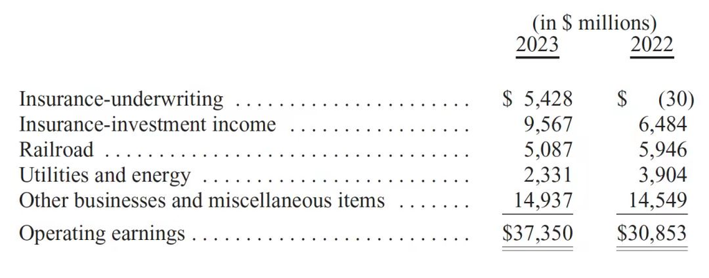

在 2023 年 5 月 6 日伯克希尔的年度聚会上，我介绍了当天一早发布的第一季度业绩。随后，我简短地总结了全年的展望：（1）2023 年，我们大多数非保险业务的盈利都将下降；（2）我们最大的两家非保险业务，伯灵顿北方圣太菲铁路运输公司（BNSF）和伯克希尔·哈撒韦能源公司（BHE）的良好业绩将缓解这一下降，这两家公司在 2022 年合计占营业收入的 30% 以上；（3）我们的投资收入肯定会大幅增长，因为伯克希尔持有的巨额美国国债头寸终于开始向我们支付远高于预期的收益。伯克希尔持有的巨额美国国库券头寸终于开始向我们支付远高于以往的微薄收益；(4) 保险业可能会有不错的表现，这是因为保险业的承保收益与经济中其他领域的收益并不相关，此外，财产保险价格已经走强。

保险的情况正如预料。不过，我对 BNSF 和 BHE 的预期有误。让我们分别来看看。

铁路对美国经济的未来至关重要。从成本、燃料使用和碳强度等方面衡量，铁路显然是将重型材料运往遥远目的地的最有效方式。卡车运输在短途运输中胜出，但美国人需要的许多货物必须运往数百甚至数千英里之外的客户手中。没有铁路，美国就无法运转，铁路行业的资金需求始终是巨大的。事实上，与大多数美国企业相比，铁路行业非常“吃”资本。

BNSF 是覆盖北美的六大铁路系统中最大的一家。我们的铁路拥有 23759 英里长的主轨道、99 条隧道、13495 座桥梁、7521 台机车和其他各种固定资产，资产负债表上的价值高达 700 亿美元。但据我猜测，复制这些资产至少需要 5000 亿美元，而完成这项工作则需要数十年的时间。

BNSF 每年的支出必须超过折旧费用，才能维持现有的业务水平。这一现实，对所有行业的所有者都是不利的，但在资本密集型行业尤其不利。

在BNSF，自 14 年前被收购以来，超出美国通用会计准则折旧费用的支出总额达到了惊人的 220 亿美元，即每年超过 15 亿美元。哎哟！这种差距意味着，除非我们定期增加铁路公司的债务，否则支付给伯克希尔的 BNSF 股息将经常大大低于其公布的收益。但我们不打算这么做。

因此，伯克希尔公司的收购价格获得了可接受的回报，尽管比表面上看起来的要少，而且资产的重置价值也很低。我或伯克希尔董事会对此并不感到意外。这也解释了为什么我们能在 2010 年以其重置价值的一小部分买下 BNSF。

北美的铁路系统单程长途运输大量的煤炭、谷物、汽车、进出口货物等，这些运输往往会给回程运输带来收入问题。天气条件极端恶劣，经常会妨碍甚至阻碍轨道、桥梁和设备的使用。洪水可能是一场噩梦。这些还都不足为奇。虽然我坐在舒适的办公室里，但铁路运输是一项户外活动，许多员工在艰苦、有时甚至危险的条件下工作。

一个不断演变的问题是，越来越多的美国人不愿意在某些铁路运营中从事艰苦且往往孤独的工作。工程师们必须面对这样一个事实：在美国的 3.35 亿人口中，一些孤苦无依或精神失常的美国人将选择躺在 100 节车厢的超重型列车前自杀，而这种列车在不到一英里或更长的距离内是停不下来的。你想成为那个无助的工程师吗？在北美，这种创伤每天都会发生一次；在欧洲，这种情况要普遍得多，而且会一直伴随着我们。

铁路行业的工资谈判最终可能掌握在总统和国会手中。此外，美国铁路公司每天都被要求运输许多危险产品，而这是该行业宁愿避免的。“公共承运人”一词界定了铁路的责任。

去年，由于收入下降，BNSF 的盈利下降幅度超出了我的预期。虽然燃料成本也有所下降，但华盛顿颁布的工资涨幅却远远超出了国家的通胀目标。这种差异可能会在未来的谈判中再次出现。

虽然 BNSF 比北美其他五大铁路公司运载更多的货物，花费更多的资本支出，但自我们收购以来，其利润率相对于所有五大铁路公司都有所下滑。我相信，我们广阔的服务区域是首屈一指的，因此我们的利润率可以而且应该得到改善。

我尤其为 BNSF 对国家的贡献以及在北达科他州和蒙大拿州的冬季零度以下户外工作以保持美国商业动脉畅通的人们感到骄傲。铁路在正常工作时不会受到太多关注，但如果它们无法工作，整个美国都会立即注意到这一空白。

百年之后，BNSF 仍将是国家和伯克希尔的重要资产。这一点你可以放心。

去年，我们对 BHE 的收益感到失望，这也是第二次，甚至更严重。该公司大多数大型电力业务以及广泛的天然气管道业务的表现都与预期差不多。但是，一些州的监管环境已经引发了零利润甚至破产的幽灵（加利福尼亚州最大公用事业公司的实际结果和夏威夷州目前的威胁）。在这种情况下，曾经被视为美国最稳定行业之一的公用事业公司很难预测盈利和资产价值。

一个多世纪以来，电力公司通过各州承诺的固定股本回报率（有时业绩优异会有小额奖金）筹集巨额资金，为公司发展提供资金。通过这种方式，对几年后可能需要的发电能力进行了大规模投资。这种前瞻性监管反映了一个现实，即公用事业公司建设发电和输电资产往往需要多年时间。BHE 在西部的大型多州输电项目于 2006 年启动，距完工还有数年时间。该项目最终将服务于 10 个州，占美国大陆总面积的 30%。

私营和公共电力系统都采用这种模式，即使人口增长或工业需求超出预期，电灯也不会熄灭。在监管者、投资者和公众看来，这种“安全边际”方法是明智的。现在，这种“固定但令人满意的回报”模式已经在几个州被打破，投资者开始担心这种破裂会蔓延开来。气候变化加剧了他们的担忧。地下输电可能是必需的，但几十年前，谁愿意为这种建设支付高昂的费用呢？

在伯克希尔，我们对已经发生的损失金额进行了最佳估算。这些损失是由森林火灾造成的。森林火灾的频率和强度都增加了，而且如果对流风暴变得更加频繁，很可能还会继续增加。

我们还需要很多年才能知道 BHE 在森林火灾中的最终损失，才能明智地决定未来在脆弱的西部各州进行投资的可取性。其他地方的监管环境是否会发生变化，我们拭目以待。

其他电力公司可能会面临与太平洋天然气电力公司和夏威夷电力公司类似的生存问题。如果以没收的方式解决目前的问题，显然会对 BHE 造成不利影响，但它和伯克希尔本身的结构都能应对不利的意外情况。我们的基本产品是风险承担，我们在保险业务中经常会遇到这种情况，其他业务也会出现这种情况。伯克希尔公司可以承受财务意外，但我们不会故意把好钱往坏处扔。

无论伯克希尔公司的情况如何，公用事业行业的最终结果可能是凶多吉少：某些公用事业公司可能不再吸引美国公民的储蓄，将被迫采用公共电力模式。内布拉斯加州在 20 世纪 30 年代就做出了这样的选择，全国各地也有许多公共电力公司。最终，选民、纳税人和用户将决定他们更喜欢哪种模式。

当一切尘埃落定，美国的电力需求和随之而来的资本支出将是惊人的。我和伯克希尔在 BHE 的两位合伙人都没有预料到甚至没有考虑到监管回报的不利发展，我犯了一个代价高昂的错误。

不谈问题了：去年，我们的保险业务表现优异，在销售额、浮存金和承保利润方面都创下了记录。财产保险（P/C）是伯克希尔公司发展的核心。我们从事这项业务已有 57 年，尽管我们的业务量增长了近 5000 倍（从 1700 万美元增长到 830 亿美元），但我们仍有很大的增长空间。

除此之外，我们还学到了——往往是痛苦地学到了——要避免什么类型的保险业务和什么样的人。最重要的教训是，我们的承保人可以是瘦的、胖的、男的、女的、年轻的、年老的、外国的或本国的。但在办公室里，他们不能是乐观主义者，无论这种品质在生活中是多么可取。

财产保险业务中的意外几乎总是负面的，这种意外可能在六个月或一年期保单到期几十年后才出现。该行业的会计设计旨在认识到这一现实，但估算错误可能非常严重。如果涉及到江湖骗子，发现起来往往既慢又费钱。伯克希尔公司总是试图准确估计未来的损失赔付，但通货膨胀——包括货币和“法律”方面的通货膨胀——是一个不确定因素。

关于我们的保险业务，我已经讲过很多次了，所以我只想引导新读者阅读第 18 页。在此，我只想重复，如果阿吉特·贾恩没有在 1986 年加入伯克希尔，我们的地位就不会是现在这样。在那个幸运的日子到来之前，除了 1951 年初在盖可开始的一段几乎令人难以置信的美好经历之外，我一直在荒野中徘徊，努力建立我们的保险业务。

阿吉特自加入伯克希尔以来所取得的成就，得到了我们各种财险业务中一大批才华横溢的保险高管的支持。大多数媒体和公众都不知道他们的名字和面孔。然而，伯克希尔的经理人阵容对于财产保险的意义，就像库珀斯敦的获奖者对于棒球的意义一样。

伯蒂，你可以为自己拥有一家令人难以置信的财险公司的一部分而感到欣慰，这家公司目前在全球运营，拥有无与伦比的资金、声誉和人才。它在 2023 年扛起了大旗。

**奥马哈什么情况？**

来参加 2024 年 5 月 4 日伯克希尔的年度聚会。您将在台上看到三位经理人，他们现在承担着领导公司的主要责任。你可能会问，这三人有什么共同点？他们长得肯定不像。让我们深入了解一下。

格雷格·阿贝尔负责伯克希尔公司所有非保险业务。从各方面来看，出生和成长在加拿大的他（他还在打曲棍球）已经做好了明天成为伯克希尔公司首席执行官的准备。但在 20 世纪 90 年代，格雷格在奥马哈住了六年，离我只有几个街区之遥。在此期间，我从未见过他。

十多年前，在印度出生、长大并接受教育的阿吉特·贾恩与家人住在奥马哈，离我家只有一英里左右（我从 1958 年起就住的家）。阿吉特和他的妻子廷库都有很多奥马哈的朋友，尽管他们搬到纽约已经有三十多年的时间了（因为纽约是再保险行业的主要活动地）。

在公司层面，伯克希尔公司于 1970 年从居住了 81 年的新英格兰迁至奥马哈定居，抛开烦恼，在新家园茁壮成长。

作为“奥马哈效应”的最后点睛之笔，伯蒂——没错，就是伯蒂——早年在奥马哈的一个中产阶级社区度过了她的成长岁月，几十年后，她成为了美国最伟大的投资者之一。

你可能会认为，她把所有的钱都放在伯克希尔，然后就坐吃山空了。但事实并非如此。1956 年成家后，伯蒂 20 年来一直积极理财：持有债券，将 1/3 的资金投入上市共同基金，并频繁买卖股票。她的潜力一直未被发掘。

1980 年，46 岁的伯蒂在哥哥的劝说下决定离开。在接下来的 43 年里，她只保留了共同基金和伯克希尔公司，没有进行新的交易。在此期间，她变得非常富有，甚至在捐出大笔慈善捐款（9 位数）之后也是如此。

数以百万计的美国投资者本可以遵循她的推理，而她的推理只涉及她在奥马哈长大时不知不觉吸收的常识。伯蒂从不冒险，每年五月她都会回到奥马哈，然后重新焕发活力。

到底是怎么回事？是奥马哈的水吗？是奥马哈的空气吗？是类似于牙买加短跑运动员、肯尼亚马拉松运动员或俄罗斯国际象棋专家的某种奇怪的地球现象吗？我们一定要等到有一天人工智能给出这个谜题的答案吗？

保持开放的心态。五月来到奥马哈，呼吸这里的空气，喝这里的水，向伯蒂和她漂亮的女儿们问好。谁知道呢？没有什么坏处，而且，无论如何，您都会度过一段美好时光，并结识一大群友好的人。

最重要的是，我们将提供新的第 4 版《穷查理宝典》。快来买一本吧。查理的智慧将提升你的生活，就像它提升了我的生活一样。